# INTERPOLATION USING PYTHON

## By kech_cole

Interpolation methods using Python. Interpolation techniques covered include nearest neighbour, moving average, inverse distance and linear interpolation. Specific module used is Gdal, it provided all the algorithms used to determine unknown point values.

### Import modules

```python
import geopandas as gpd
import matplotlib.pyplot as plt
from osgeo import gdal
import os
import rasterio
from rasterio.plot import show
```

### Set working directory.

```python
# Change working directory

new = os.chdir(r'D:\Programs\Python\Jupiter notebook\Interpolation')

os.getcwd()
```

```
'D:\\Programs\\Python\\Jupiter notebook\\Interpolation'
```

### Import data

```
   Id  heights                  geometry
0   0    809.0  POINT (34.42706 4.10804)
1   0    655.0  POINT (35.42567 4.12511)
2   0    621.0  POINT (36.90248 3.86727)
3   0    647.0  POINT (38.15374 3.27109)
4   0    530.0  POINT (40.14202 3.04344)
GEOGCS["WGS 84",DATUM["WGS_1984",SPHEROID["WGS 84",6378137,298.257223563,AUTHORITY["EPSG","7030"]],AUTHORITY["EPSG","6326"]],PRIMEM["Greenwich",0],UNIT["Degree",0.0174532925199433],AXIS["Longitude",EAST],AXIS["Latitude",NORTH]]
```

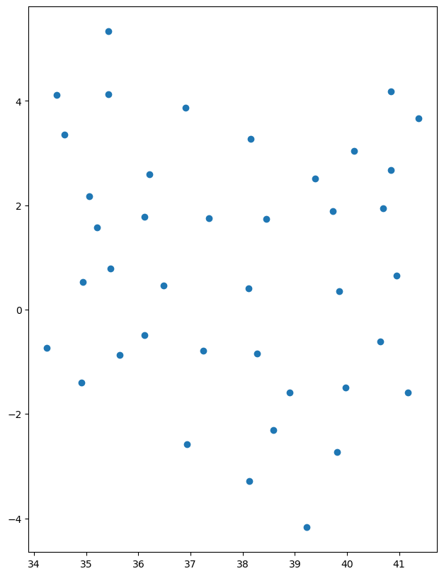

```python
# Read point shapefile and convert to geopandas dataframe

points_shp = 'Points1/POINTS.shp'
elevations = gpd.read_file(points_shp)

print(elevations.head())
print(elevations.crs)

# Plot point geodataframe.
elevations.plot(figsize=(10, 10))
plt.show()
```

```python
# Column names
elevations.columns
```

```
Index(['Id', 'heights', 'geometry'], dtype='object')
```

```python
# Bounding box of the shapefile
elevations.total_bounds
```

```
array([34.2487833 , -4.17304317, 41.36917466,  5.33150703])
```

```python
# Access first element
elevations.total_bounds[0]
```

```
34.248783299099216
```

# Interpolation methods

## 1. Nearest neighbour

```python
# Create nearest neighbour interpolation

nn = gdal.Grid('nearest_neighbour.tif',             # Output file
               points_shp,                          # Input file
               zfield='heights',                    # Column containing heights
               algorithm='nearest')                 # Nearest neighbour algorithm used

nn = None       # Close file
```

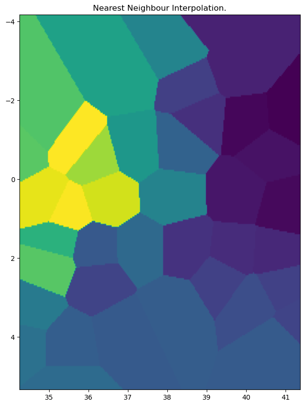

```
Spatial extend -  BoundingBox(left=34.248783299099216, bottom=5.331507028384183, right=41.36917466315609, top=-4.173043167976236)
```

```python
# Open and plot tif image
nearest = rasterio.open('nearest_neighbour.tif')

# Plot
fig, ax = plt.subplots(figsize=(10, 10))
show(nearest, cmap='viridis', ax=ax)
plt.title('Nearest Neighbour Interpolation.')
plt.show()

print('Spatial extend - ',nearest.bounds)
```

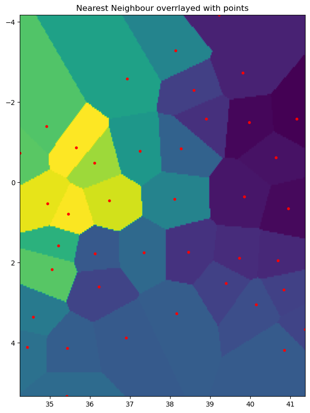

```python
# Overlay raster with points shapefile.

fig, ax = plt.subplots(figsize=(10, 10))
show(nearest, cmap='viridis', ax=ax)
elevations.plot(color="red", ax=ax, markersize=10)
plt.title('Nearest Neighbour overrlayed with points')
plt.show()
```

### Transform parameters

Transform values provide critical information that can be used to define the coordinate limits (width, height, bounds) of the tiff generated. This makes the output file to have similar extent and resolution as original file.

```python
# Get transform values, all values will be in degrees because data unit is in degrees.
print('Resolution - ', nearest.transform[0])


# The product of this matrix and (0, 0), the row and column coordinates of the upper left corner of the dataset,
# spatial position of the upper left corner.

top_rightCoordinates = nearest.transform * (nearest.width, nearest.height)   # Tuple
urx = top_rightCoordinates[0]             # Top right x coordinates
ury = top_rightCoordinates[1]             # Top right y coordinates


bottom_leftCoordinates = nearest.transform * (0, 0)    # Tuple
llx = bottom_leftCoordinates[0]                    # Lower left x coordinates
lly = bottom_leftCoordinates[1]                    # Lower right y coordinates

# Lower right corner
print('\n\nCoordinates of the bottom left y1(llx), x2(lly) - ', llx, lly)

# Top right corner
print('\n\nCoordinates of the top right y2(urx), x1(ury) - ', urx, ury)

# Alternatively, one can list items in bounds method.
print('\n\n Bounds method objects - ',nearest.bounds[0], nearest.bounds[1], nearest.bounds[2], nearest.bounds[3])
```

```
Resolution -  0.027814028765847154


Coordinates of the bottom left y1(llx), x2(lly) -  34.248783299099216 -4.173043167976236


Coordinates of the top right y2(urx), x1(ury) -  41.36917466315609 5.331507028384183


 Bounds method objects -  34.248783299099216 5.331507028384183 41.36917466315609 -4.173043167976236
```

## 2. Moving Average

Sets up a search ellipse around an unknown data point and then averages the known points inside the ellipse and assign that value. This algorithm keeps shifting elliptic window from one unknown point to the other till all points are assigned a weight value.

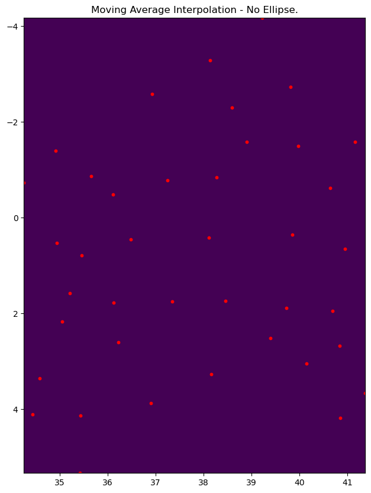

```python
# Create a moving average interpolation

# Without an elipse
mov_avg = gdal.Grid('moving_avg.tif', points_shp, zfield='heights',
               algorithm='average',                                    # Algorithm name
               outputBounds = [llx, lly, urx, ury],
               width = nearest.width, height = nearest.height)
mov_avg  = None

# Open image
moving_avg = rasterio.open('moving_avg.tif')

# Plot
fig, ax = plt.subplots(figsize=(10, 10))
show(moving_avg, cmap='viridis', ax=ax)
elevations.plot(color="red", ax=ax, markersize=10)
plt.title('Moving Average Interpolation - No Ellipse.')
plt.show()

# All pixels are assigned a single value(average height of all points).
```

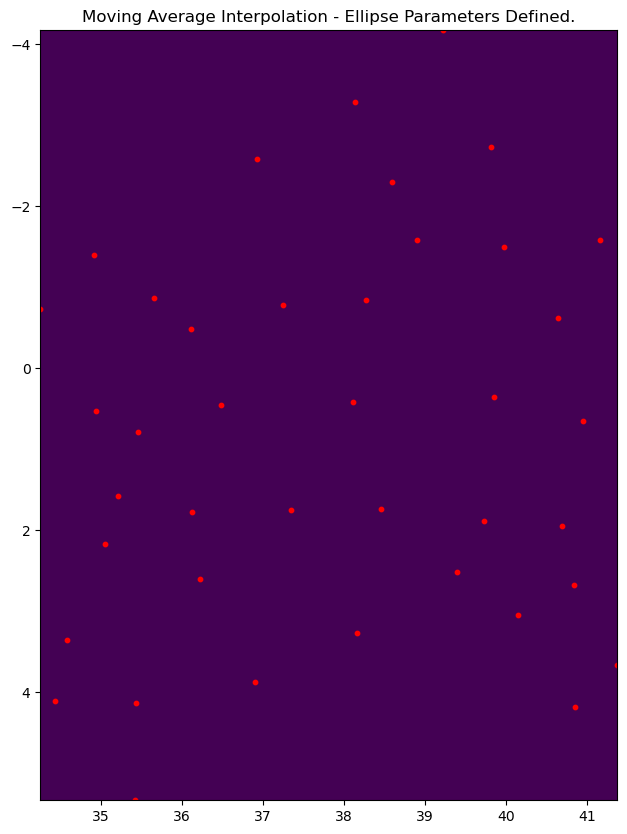

```python
# Create a moving average with elipse defined

# With elipse defined other parameters defined
mov_avg = gdal.Grid('moving_avg_e1.tif', points_shp, zfield='heights',
               # Add semi-major axis radius = 150km, semi-minor radius = 100km and clockwise rotation angle = 20 degrees.
               algorithm='average:radius1=150000:radius2=100000:angle=20',
               outputBounds = [llx, lly, urx, ury],
               width = nearest.width, height = nearest.height)
mov_avg  = None

# Open tif image
moving_avg1 = rasterio.open('moving_avg_e1.tif')

# Plot
fig, ax = plt.subplots(figsize=(10, 10))
show(moving_avg1, cmap='viridis', ax=ax)
elevations.plot(color="red", ax=ax, markersize=10)
plt.title('Moving Average Interpolation - Ellipse Parameters Defined.')
plt.show()
```

## 3. IDW (Inverse distance weight)

IDW is an interpolator that uses weighted average of known points to determine the values of unknown. Closer values are assigned greater influence than ones located further from an unknown point. Weight is a function of distance.

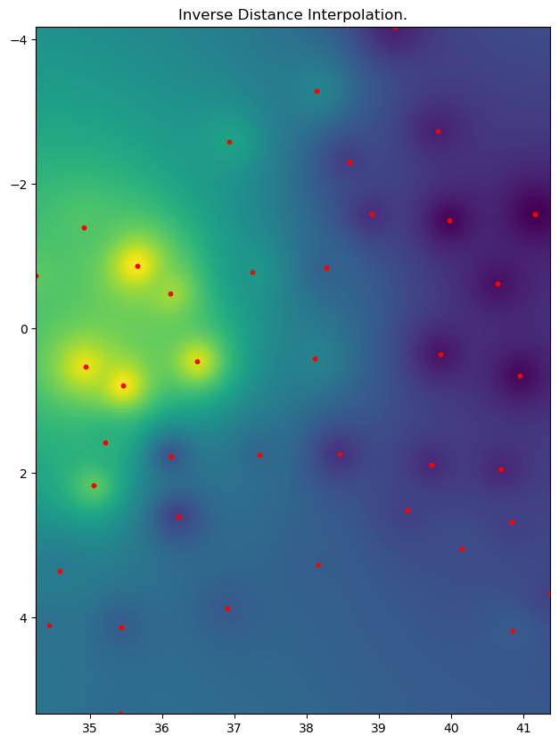

```python
# Create an inverse distance weight interpolation and plot


idw = gdal.Grid('idw.tif', points_shp, zfield='heights',
               algorithm='invdist',                        # This is the default algorithm thus is not compulsory.
               outputBounds = [llx, lly, urx, ury],
               width = nearest.width, height = nearest.height)
idw = None

# Open tif image
idw = rasterio.open('idw.tif')

# Plot image
fig, ax = plt.subplots(figsize=(10, 10))
show(idw, cmap='viridis', ax=ax)
elevations.plot(color="red", ax=ax, markersize=10)
plt.title('Inverse Distance Interpolation.')
plt.show()
```

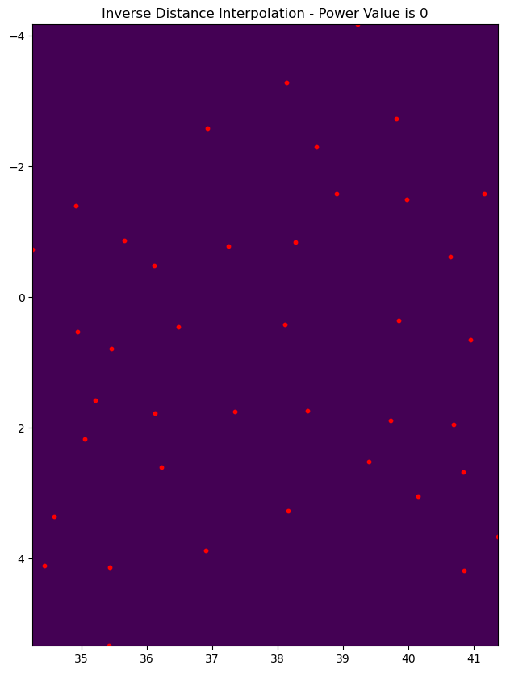

```python
# Use a weighting power of 0 to create a second inverse distance weight plot.

# Here weight assigned to points will not decrease with distance between values. All known elevation values will be
# averaged and this value assigned to all unknown points since they are given the same weight.

idw2 = gdal.Grid('idw1.tif', points_shp, zfield='heights',
               algorithm='invdist:power=0',                        # Assign a power value 0
               outputBounds = [llx, lly, urx, ury],                # Spatial limits
               width = nearest.width, height = nearest.height)
idw2 = None

# Open and plot tif image
idw = rasterio.open('idw1.tif')

# Plot
fig, ax = plt.subplots(figsize=(10, 10))
show(idw, cmap='viridis', ax=ax)
elevations.plot(color="red", ax=ax, markersize=10)
plt.title('Inverse Distance Interpolation - Power Value is 0')
plt.show()
```

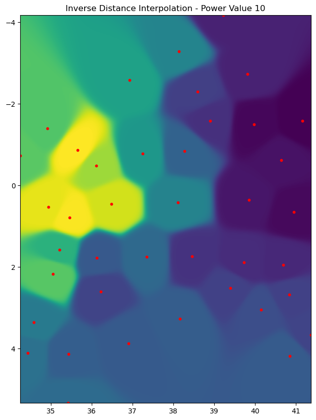

```python
# Use a weighting power of 10 to create a third inverse distance weight plot.

# Points with higher proximity will be assigned greater weight while those further away are given less weight, similar to
# nearest neighbour interpolation.

idw3 = gdal.Grid('idw2.tif', points_shp, zfield='heights',
               algorithm='invdist:power=10',                        # Assign a power value 10
               outputBounds = [llx, lly, urx, ury],
               width = nearest.width, height = nearest.height)
idw3 = None

# Open and plot tif image
idw = rasterio.open('idw2.tif')

# Plot
fig, ax = plt.subplots(figsize=(10, 10))
show(idw, cmap='viridis', ax=ax)
elevations.plot(color="red", ax=ax, markersize=10)
plt.title('Inverse Distance Interpolation - Power Value 10')
plt.show()
```

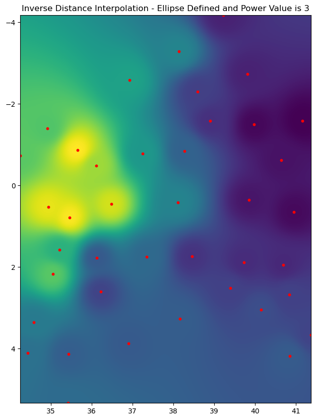

```python
# Use a weighting power of 3 to create the fourth inverse distance weight plot.

# Points that lie further will have little to no influence.
# To specify the distance from which all points beyond it will not affect weight, one has to provide a radius of influence.

idw4 = gdal.Grid('idw3.tif', points_shp, zfield='heights',
                 # Assign a power=3 and points lying more than 200km will not have an influence.
               algorithm='invdist:power=3:radius1=200000:radius2=200000',
               outputBounds = [llx, lly, urx, ury],
               width = nearest.width, height = nearest.height)
idw4 = None

# Open and plot tif image
idw = rasterio.open('idw3.tif')

# Plot
fig, ax = plt.subplots(figsize=(10, 10))
show(idw, cmap='viridis', ax=ax)
elevations.plot(color="red", ax=ax, markersize=10)
plt.title('Inverse Distance Interpolation - Ellipse Defined and Power Value is 3')
plt.show()
```

## 4. Linear Interpolation.

Uses Delaunay triangles between points to assign values.

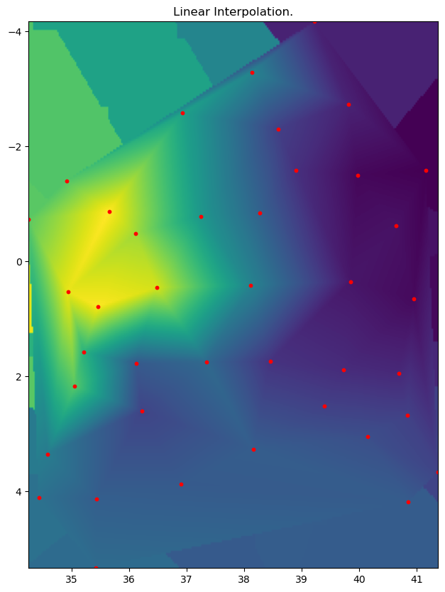

```python
# Create a linear interpolation and plot.

ln = gdal.Grid('linear.tif', points_shp, zfield='heights',
               algorithm='linear',
               outputBounds = [llx, lly, urx, ury],
               width = nearest.width, height = nearest.height)
ln = None

# Open and plot tif image
linear = rasterio.open('linear.tif')

# Plot
fig, ax = plt.subplots(figsize=(10, 10))
show(linear, cmap='viridis', ax=ax)
elevations.plot(color="red", ax=ax, markersize=10)
plt.title('Linear Interpolation.')
plt.show()
```

References

1. GDAL Documentation - https://gdal.org/
2. Python Language version 3.9.13 - http://www.python.org/
3. Matplotlib - https://matplotlib.org/
4. Geopandas - https://geopandas.org/en/stable/docs/user_guide
5. Rasterio - https://rasterio.readthedocs.io/en/latest/